# Homework 3

Author

Anthony Cu (PSTAT 134/234)

## Homework 3

Star Trek ships.

For this homework assignment, we’ll be working with a dataset called [Spaceship Titanic](https://www.kaggle.com/competitions/spaceship-titanic/overview). It is a simulated dataset used for a popular Kaggle competition, intended to be similar to the very famous Titanic dataset. The premise of the Spaceship Titanic data is that it is currently the year 2912. You have received a transmission from four lightyears away, sent by the Spaceship Titanic, which was launched a month ago.

The Titanic set out with about 13,000 passengers who were emigrating from our solar system to three newly habitable exoplanets. However, it collided with a spacetime anomaly hidden in a dust cloud, and as a result, although the ship remained intact, half of the passengers on board were transported to an alternate dimension. Your challenge is to predict which passengers were transported, using records recovered from the spaceship’s damaged computer system.

The dataset is provided in `/data`, along with a codebook describing each variable. You should read the dataset into your preferred coding language (R or Python) and familiarize yourself with each variable.

We will use this dataset for the purposes of practicing our data visualization and feature engineering skills.

```python
import numpy as np
import pandas as pd
import seaborn as sns
import matplotlib.pyplot as plt
import re
from sklearn.preprocessing import StandardScaler

titanic = pd.read_csv('~/pstat-134-234/Homework/Homework 3/data/spaceship_titanic.csv')
```

### Exercise 1

Which variables have missing values? What percentage of these variables is missing? What percentage of the overall dataset is missing?

```python
# titanic.isnull().sum(), titanic.isna().sum() returns the same

for col in titanic.columns.tolist():
  print('{} column missing values: {}'.format(col, titanic[col].isnull().sum()))
```

```
PassengerId column missing values: 0
HomePlanet column missing values: 201
CryoSleep column missing values: 217
Cabin column missing values: 199
Destination column missing values: 182
Age column missing values: 179
VIP column missing values: 203
RoomService column missing values: 181
FoodCourt column missing values: 183
ShoppingMall column missing values: 208
Spa column missing values: 183
VRDeck column missing values: 188
Name column missing values: 200
Transported column missing values: 0
```

> All variables (except for PassengerID and Transported) have missing values. I searched for all null (and NA) values in the columns and calculated the total of these entries. I print the missing percentage of each of the variables:

```python
for w in titanic.columns:
  missing_prop = titanic[w].isnull().sum() / len(titanic)
  print(f"{w}: {missing_prop:.2%}")
```

```
PassengerId: 0.00%
HomePlanet: 2.31%
CryoSleep: 2.50%
Cabin: 2.29%
Destination: 2.09%
Age: 2.06%
VIP: 2.34%
RoomService: 2.08%
FoodCourt: 2.11%
ShoppingMall: 2.39%
Spa: 2.11%
VRDeck: 2.16%
Name: 2.30%
Transported: 0.00%
```

```python
((titanic.isnull().sum()).sum() / titanic.size)
```

```
np.float64(0.019095824226389047)
```

> In total of the entire dataframe, about 1.91% of the total data is missing.

### Exercise 2

Use mode imputation to fill in any missing values of `home_planet`, `cryo_sleep`, `destination`, and `vip`. Drop any observations with a missing value of `cabin` (there are too many possible values).

Use median imputation to fill in any missing values of `age`. Rather than imputing with the overall mean of `age`, impute with the median age of the corresponding `vip` group. (For example, if someone who is a VIP is missing their age, replace their missing age value with the median age of all passengers who are **also** VIPs).

For passengers missing any of the expenditure variables (`room_service`, `food_court`, `shopping_mall`, `spa`, or `vr_deck`), handle them in this way:

- If all their observed expenditure values are $0$, **or** if they are in cryo-sleep, replace their missing value(s) with $0$.
- For the remaining missing expenditure values, use mean imputation.

```python
titanic_cleaned = titanic.copy()

# mode imputation
for i in ['HomePlanet', 'CryoSleep', 'Destination', 'VIP']:
  titanic_cleaned[i] = titanic_cleaned[i].fillna(titanic_cleaned[i].mode()[0])
# drop observations that are missing values in cabin
titanic_cleaned = titanic_cleaned.dropna(subset=['Cabin'])

# median imputation
age_medians = titanic_cleaned.groupby(['VIP'])['Age'].transform(lambda x: x.fillna(x.median()))

titanic_cleaned['Age'] = titanic_cleaned['Age'].fillna(age_medians)

# alternate approach (not vectorized function)
# median_VIP = titanic_cleaned[titanic_cleaned['VIP'] == True]['Age'].median()
# median_no_VIP = titanic_cleaned[titanic_cleaned['VIP'] == False]['Age'].median()
#
# titanic_cleaned.loc[(titanic_cleaned['VIP'] == True) & (titanic_cleaned['Age'].isnull()), 'Age'] = median_VIP
# titanic_cleaned.loc[(titanic_cleaned['VIP'] == False) & (titanic_cleaned['Age'].isnull()), 'Age'] = median_no_VIP

# missing by expenditure values

# to check if any of these observations are missing or if any of these observations equal 0 OR if the crysleep is true
expenditures = ['RoomService', 'FoodCourt', 'ShoppingMall', 'Spa', 'VRDeck']
rows_to_0 = np.all((titanic_cleaned[expenditures] == 0) | titanic_cleaned[expenditures].isnull(), axis=1) | (titanic_cleaned['CryoSleep'] == True)

# impute the entires with 0s
titanic_cleaned.loc[rows_to_0, expenditures] = 0

# for remaining mean imputation (not for condition)
for i in ['RoomService', 'FoodCourt', 'ShoppingMall', 'Spa', 'VRDeck']:
  titanic_cleaned[i] = titanic_cleaned[i].fillna(titanic_cleaned[i].mean())

# we check that we have successfully filled in missing values
titanic_cleaned.isnull().sum()
```

```
PassengerId       0
HomePlanet        0
CryoSleep         0
Cabin             0
Destination       0
Age               0
VIP               0
RoomService       0
FoodCourt         0
ShoppingMall      0
Spa               0
VRDeck            0
Name            198
Transported       0
dtype: int64
```

### Exercise 3

What are the proportions of both levels of the outcome variable, `transported`, in the dataset?

```python
transport_levels = titanic_cleaned['Transported'].value_counts()

transport_levels / transport_levels.sum()
```

```
Transported
True     0.50365
False    0.49635
Name: count, dtype: float64
```

> 50.37% of the variables are transported, while 49.63% of the variables are not transported.

### Exercise 4

Make proportion stacked bar charts of each of the following. Describe what patterns, if any, you observe.

1. `home_planet` and `transported`
2. `cryo_sleep` and `transported`
3. `destination` and `transported`
4. `vip` and `transported`

[figure not shown]

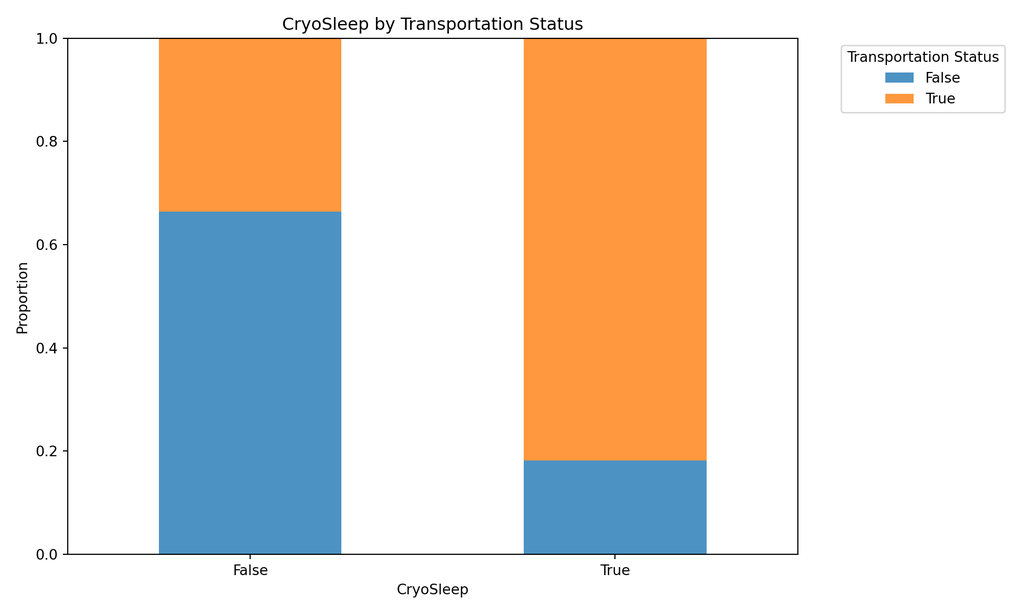

[figure not shown]

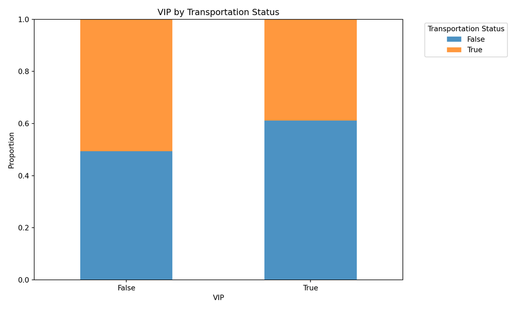

```python
# proportion stacked bar charts of transportation status filled by classes
for i in ['HomePlanet', 'CryoSleep', 'Destination', 'VIP']:
  # Calculate counts of each class by home planet
  count_data = titanic_cleaned.groupby([i, 'Transported']).size().reset_index(name='count')

  # Calculate the total counts for each home planet
  total_counts = count_data.groupby(i)['count'].transform('sum')

  # Calculate the proportion
  count_data['proportion'] = count_data['count'] / total_counts

  # Create a pivot table for better plotting
  pivot_data = count_data.pivot(index=i, columns='Transported', values='proportion').fillna(0)

  # Plotting
  plt.figure(figsize=(10, 6))

  # Stack the bars
  pivot_data.plot(kind='bar', stacked=True, ax=plt.gca(), alpha=0.8)

  # Set y-axis limits
  plt.ylim(0, 1)
  plt.title(f"{i} by Transportation Status", loc='center')
  plt.xlabel(i)
  plt.xticks(np.arange(len(titanic_cleaned[i].unique())), labels=titanic_cleaned[i].unique(), rotation=0)
  plt.ylabel("Proportion")

  # Customize the legend
  plt.legend(title="Transportation Status", bbox_to_anchor=(1.05, 1), loc='upper left')
  plt.tight_layout()

  # Show the plot
  plt.show()
  plt.close()
```

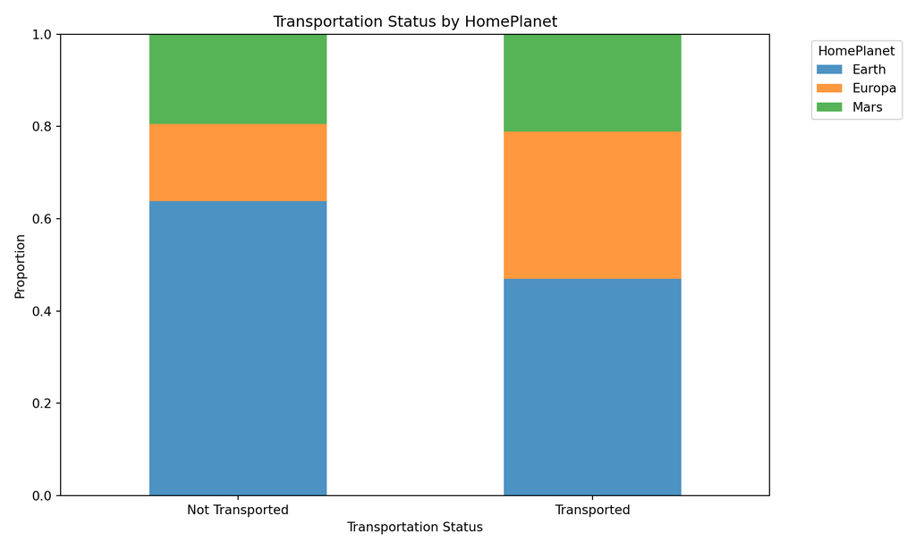

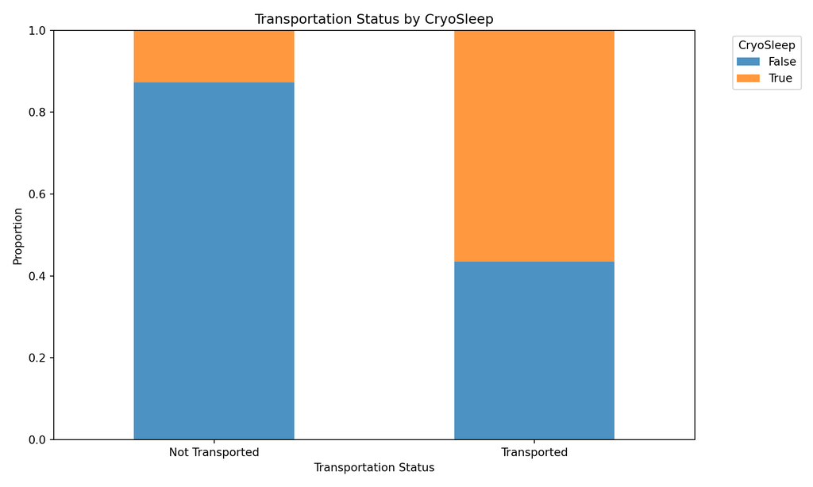

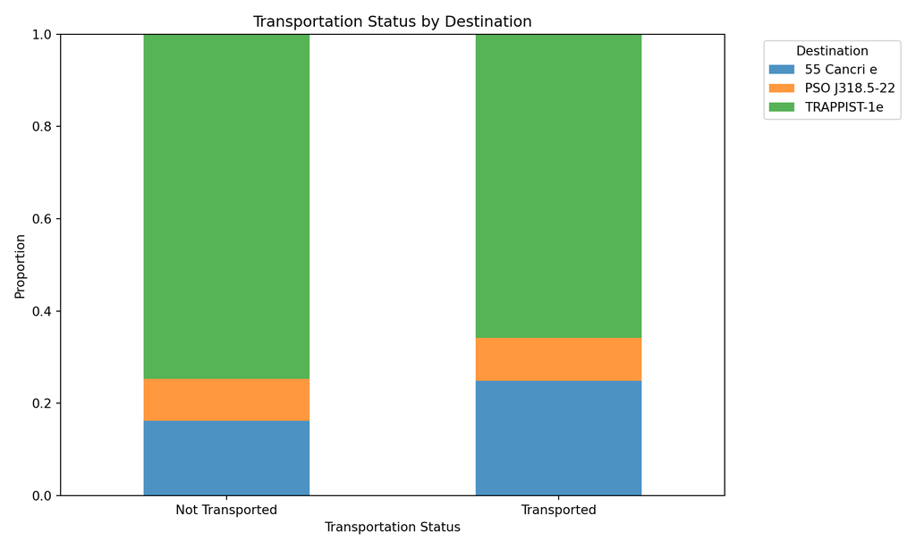

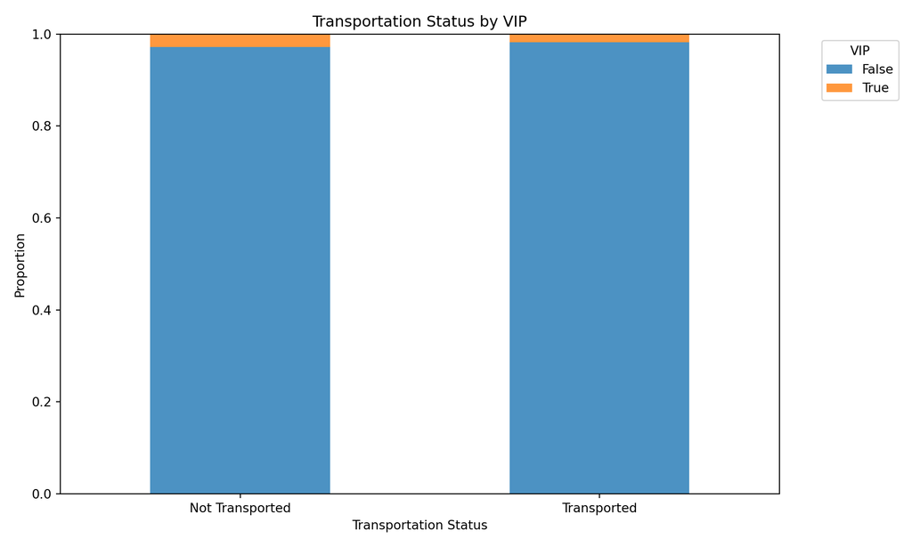

```python
# proportion stacked bar charts of classes filled by transportation status
for i in ['HomePlanet', 'CryoSleep', 'Destination', 'VIP']:
  # Calculate counts of each class by home planet
  count_data = titanic_cleaned.groupby(['Transported', i]).size().reset_index(name='count')

  # Calculate the total counts for each home planet
  total_counts = count_data.groupby('Transported')['count'].transform('sum')

  # Calculate the proportion
  count_data['proportion'] = count_data['count'] / total_counts

  # Create a pivot table for better plotting
  pivot_data = count_data.pivot(index='Transported', columns=i, values='proportion').fillna(0)

  # Plotting
  plt.figure(figsize=(10, 6))

  # Stack the bars
  pivot_data.plot(kind='bar', stacked=True, ax=plt.gca(), alpha=0.8)

  # Set y-axis limits
  plt.ylim(0, 1)
  plt.title(f"Transportation Status by {i}", loc = 'center')
  plt.xlabel('Transportation Status')
  plt.xticks(ticks=[0, 1], labels=['Not Transported', 'Transported'], rotation=0)
  plt.ylabel("Proportion")

  # Customize the legend
  plt.legend(title=i, bbox_to_anchor=(1.05, 1), loc='upper left')
  plt.tight_layout()

  # Show the plot
  plt.show()
  plt.close()
```

### Exercise 5

Using box plots, density curves, histograms, dot plots, or violin plots, compare the distributions of the following and describe what patterns you observe, if any.

1. `age` across levels of `transported`
2. `room_service` across levels of `transported`
3. `spa` across levels of `transported`
4. `vr_deck` across levels of `transported`

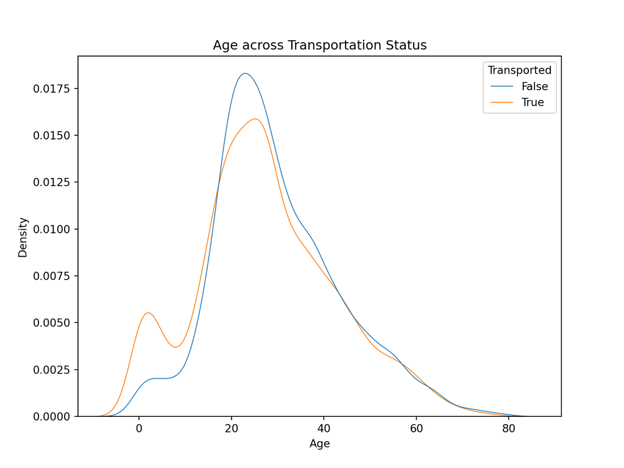

```python
plt.figure(figsize=(8, 6))
sns.kdeplot(data=titanic_cleaned, x='Age', hue='Transported', linewidth=0.75)

# Add labels and title
plt.title("Age across Transportation Status")
plt.xlabel("Age")
plt.ylabel("Density")

# Show the plot
plt.show()
```

```python
plt.close()
```

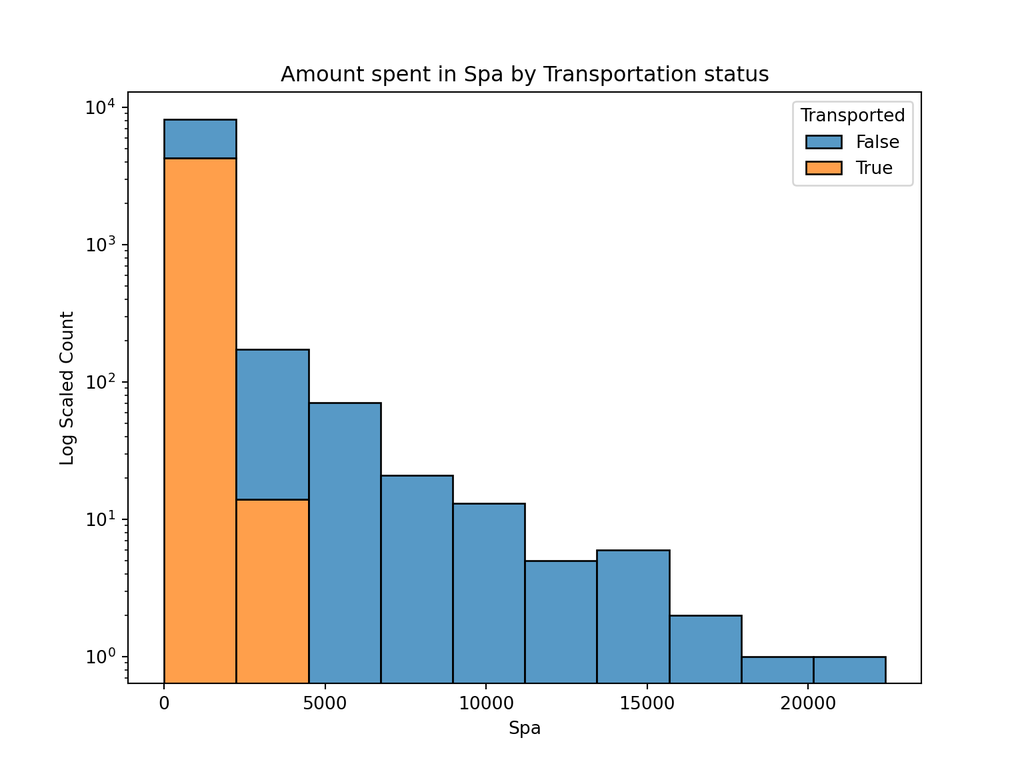

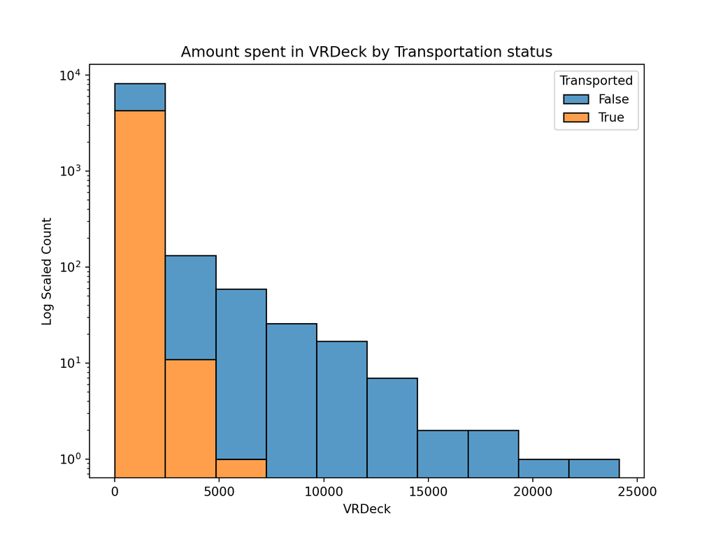

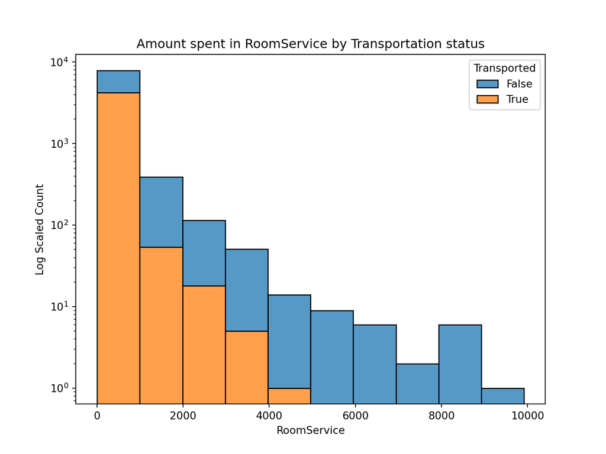

```python
# considerations: log normalize?
for i in ['Spa', 'VRDeck', 'RoomService']:
  plt.figure(figsize=(8, 6))
  sns.histplot(data=titanic_cleaned, x=i, hue='Transported', bins=10, edgecolor='black', stat='count', multiple='stack')

  # Add labels and title
  plt.yscale('log')
  plt.title(f"Amount spent in {i} by Transportation status")
  plt.xlabel(i)
  plt.ylabel("Log Scaled Count")

  # Show the plot
  plt.show()
  plt.close()
```